# Tipologia i Cicle de Vida de les Dades. Pràctica 2

Salvador Sanchis Beneseit* i *Joan Manuel Lopez Ruiz

5 June de 2022

# 1. Introducció. Descripció del dataset

Hem utilitzat el dataset “Titanic: Machine Learning from Disaster”, disponible a https://www.kaggle.com/c/titanic

Aquest famós joc de dades conté informació sobre els passatgers que viatjaven al Titanic quan es va enfonsar, el 15 d’Abril del 1912. Les variables incloses en el joc de dades són:

| **Variable** | **Definition** | **Key** |
| --- | --- | --- |
| survival | Ha sobreviscut | 0 = No, 1 = Sí |
| pclass | Classe | 1 = 1a, 2 = 2a, 3 = 3a |
| sex | Gènere |  |
| Age | Edat en anys |  |
| sibsp | # de germans / cònjuges a bord |  |
| parch | # de pares / fills a bord |  |
| ticket | Número de bitllet |  |
| fare | Preu del bitllet |  |
| cabin | Número de cabina |  |
| embarked | Port d’embarcament | C = Cherbourg, Q = Queenstown, S = Southampton |

A la pàgina de Kaggle, com que el dataset es presenta com a material de base per a un exercici de machine learning, es divideix el datatset en un grup ‘train’ i un grup ‘test’. La idea és utilitzar el grup ‘train’ per elaborar un model que pugui predir la supervivència dels passatgers del grup ‘test’.

Nosaltres, en canvi, utilitzem aquest dataset per fer un estudi d’interès sociològic/històric, en el qual no ens centrem en l’accident del Titanic ni en els índexs de supervivència, sinó que aprofitem la informació del dataset per aprofundir sobre factors demogràfics i econòmics que ens ajudin a construir una imatge del moviment migratori envers els EUA a principis del segle XX. En aquest sentit doncs, utilitzarem el joc de dades complet, ajuntant els grups ‘train’ i ‘test’ i descartant la variable ‘survival’, i plantejarem preguntes com: viatjar era més car pels homes que per les dones? Els preus dels bitllets es definien tenint en compte l’edat del passatger? Viatjaven més nens a tercera classe que a primera? Viatjaven més homes joves a tercera classe?

# 2. Integració i selecció de les dades d’interès a analitzar

Importem el dataset, disponible a [<https://www.kaggle.com/c/titanic>](https://www.kaggle.com/c/titanic)

```r
train <- read.csv("train.csv")
test <- read.csv("test.csv")
```

Ajuntem els dos datasets, seleccionant-ne només les variables que ens interessen pel nostre estudi: ‘Pclass’, ‘Name’, ‘Sex’, ‘Age’, ‘Fare’ i ‘Embarked’.

```r
train2 <- train[,c(3:6, 10, 12)]
test2 <- test[,c(2:5, 9, 11)]

titan <- rbind(train2, test2)
```

Transformem a factor diverses de les variables:

```r
titan$Pclass <- as.factor(titan$Pclass)
titan$Sex <- as.factor(titan$Sex)
titan$Embarked <- as.factor(titan$Embarked)
```

# 3. Neteja de les dades

## 3.1 Zeros o elements buits

Veiem que hi ha 263 valors buits a la variable ‘Age’:

```r
colSums(is.na(titan))
```

```
##   Pclass     Name      Sex      Age     Fare Embarked
##        0        0        0      263        1        0
```

Per analitzar com es distribueix la variable Age més enllà dels valors que manquen, separem el conjunt de dades amb valors buits. Primer de tot, generarem una nova columna, anomenada ‘title’, que ens permetrà mostrar la relació entre l’edat i el títol nominatiu dels passatgers:

```r
titan$ext_1 <- sub(".*, ", "", titan$Name)
titan$title <- sub(" .*", "", titan$ext_1)
levels(as.factor(titan$title))
```

```
##  [1] "Capt."     "Col."      "Don."      "Dona."     "Dr."       "Jonkheer."
##  [7] "Lady."     "Major."    "Master."   "Miss."     "Mlle."     "Mme."
## [13] "Mr."       "Mrs."      "Ms."       "Rev."      "Sir."      "the"
```

```r
no_na_titan <- titan[!is.na(titan$Age),]
na_titan <- titan[is.na(titan$Age),]
```

Ara mostrem com es distribueix l’edat en funció de la classe:

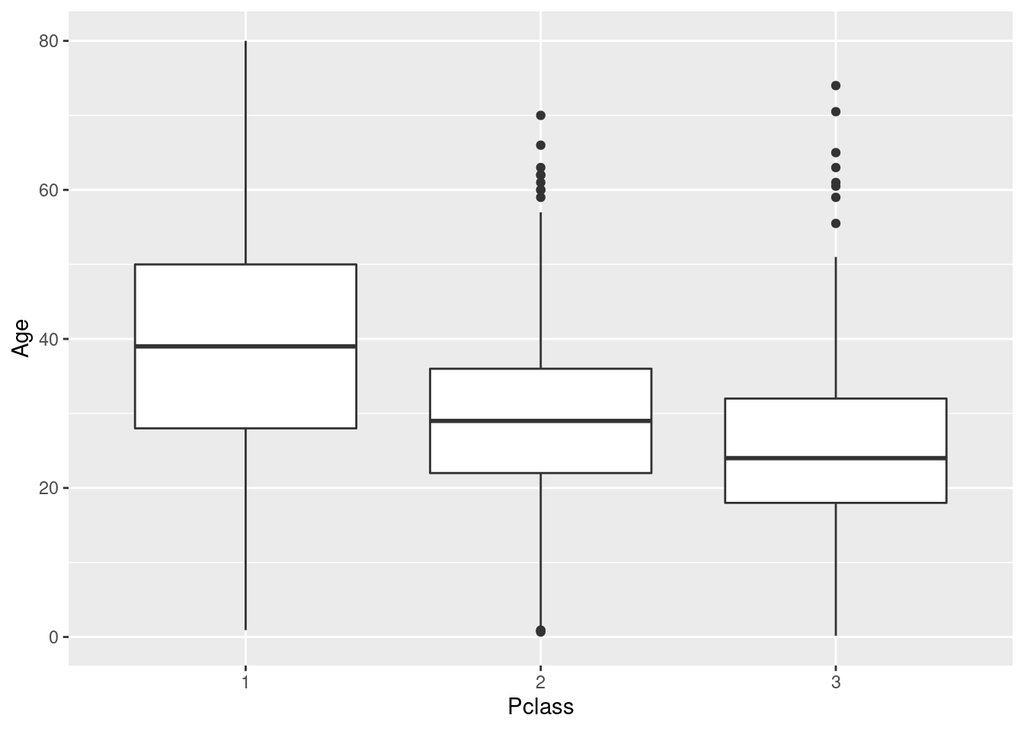

```r
library(ggplot2)
ggplot(aes(y=Age, x=Pclass), data=no_na_titan) + geom_boxplot()
```

I també podem mostrar com diferents títols defineixen diferents grups d’edat:

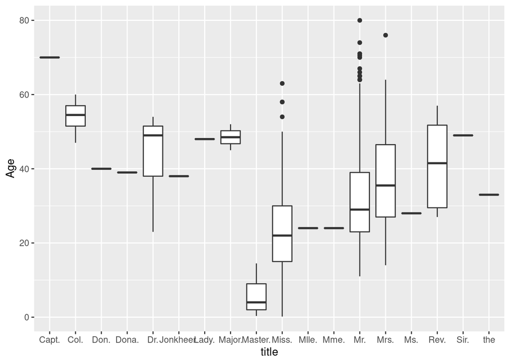

```r
library(ggplot2)
ggplot(aes(y=Age, x=title), data=no_na_titan) + geom_boxplot()
```

Donades aquestes diferències, intentarem trobar valors encara més precisos en la intersecció de les variables classe i títol.

La idea que plantegem doncs per tal d’imputar els 263 valors absents de la variable edat és crear diversos subgrups per tal de fer una aproximació més precisa a la possible edat de les persones. En primer lloc, utilitzem el fet que el títol (Mr., Miss., etc.) té una relació amb l’edat. L’exemple més clar és el títol ‘Master’, que s’utilitza només per a nens. Els altres grups no són tan reduïts, però sí que detectem una mitjana d’edat diferent en el grup Mr. que en el grup Mrs.

```r
first_cl <- no_na_titan[no_na_titan$Pclass == 1,]
second_cl <- no_na_titan[no_na_titan$Pclass == 2,]
third_cl <- no_na_titan[no_na_titan$Pclass == 3,]
```

Abans de procedir, comprovem també si la variable ‘Fare’ pot tenir relació amb l’edat. Imaginàvem que potser l’edat es veu reflectida en el preu dels bitllets. Veiem però que no es dóna aquesta correlació:

```r
cor(second_cl$Age, second_cl$Fare)
```

```
## [1] -0.1855229
```

Mostrem quins són els títols dels registres amb valors nuls, i veiem que no caldrà utilitzar tots els títols. Només manquen valors en els títols següents:

```r
levels(as.factor(na_titan$title))
```

```
## [1] "Dr."     "Master." "Miss."   "Mr."     "Mrs."    "Ms."
```

Iniciem doncs el procés d’imputació prenent com a referència classe i títol.

Comencem pels registres amb títol Dr. Primer mostrem en quina combinació del títol Dr. i classe hi ha valors buits:

```r
titan$Age[titan$title == "Dr." & titan$Pclass == 1]
```

```
## [1] 44 32 50 NA 49 53
```

```r
titan$Age[titan$title == "Dr." & titan$Pclass == 2]
```

```
## [1] 54 23
```

```r
titan$Age[titan$title == "Dr." & titan$Pclass == 3]
```

```
## numeric(0)
```

Veiem que en aquest cas, només hi ha un valor buit en passatgers amb títol Dr. de primera classe (a segona no hi ha Dr. amb valors buits, i a tercera no hi ha cap passatger amb títol Dr.)

```r
mdr1 <- mean(no_na_titan$Age[no_na_titan$title == "Dr." & no_na_titan$Pclass == 1])
mdr2 <- mean(no_na_titan$Age[no_na_titan$title == "Dr." & no_na_titan$Pclass == 2])
```

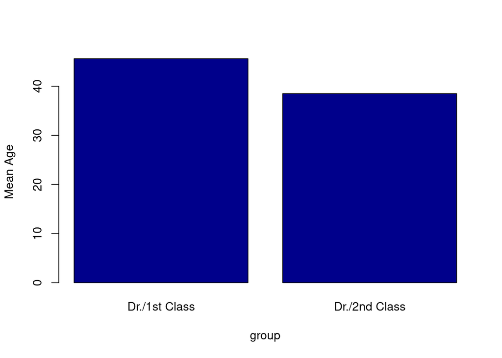

```r
dr <- c(mdr1, mdr2)
barplot(dr, xlab = 'group', ylab = 'Mean Age', names.arg = c('Dr./1st Class', 'Dr./2nd Class'), col = 'darkblue')
```

Comprovem que no hi hagi outliers en la distribució de passatgers amb títol Dr. a 1a classe:

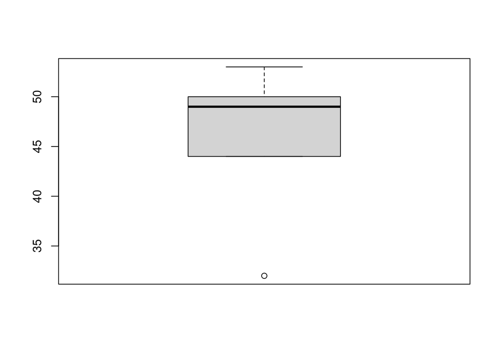

```r
boxplot(first_cl$Age[first_cl$title == "Dr."])
```

```r
boxplot.stats(first_cl$Age[first_cl$title == "Dr."])$out
```

```
## [1] 32
```

Veiem que, efectivament, hi ha un valor extrem baix que té un efecte sobre la mitjana. Optem per utilitzar la mediana en lloc de la mitjana per trobar una edat més central en la distribució del grup. Imputem doncs el valor NA per títol Dr. i primera classe en el dataset original utilitzant la mediana d’edat de passatgers Dr. de primera classe provinent del dataset que no conté valors nuls:

```r
imp_dr_1 <- median(first_cl$Age[first_cl$title == "Dr."])
imp_dr_1
```

```
## [1] 49
```

```r
titan$Age[is.na(titan$Age) & titan$title == "Dr." & titan$Pclass == 1] <- imp_dr_1
titan$Age[titan$title == "Dr." & titan$Pclass == 1]
```

```
## [1] 44 32 50 49 49 53
```

Realitzarem a partir d’aquí el mateix procediment per cadascun dels grups que es creen en la intersecció dels factors classe i títol.

Trobem els valors buits pels passatgers amb títol ‘Master.’:

```r
titan$Age[titan$title == "Master." & titan$Pclass == 1]
```

```
## [1]  0.92  4.00 11.00 13.00  6.00
```

```r
titan$Age[titan$title == "Master." & titan$Pclass == 2]
```

```
##  [1] 0.83 1.00 3.00 2.00 3.00 8.00 0.67 1.00 0.83 2.00 8.00
```

```r
titan$Age[titan$title == "Master." & titan$Pclass == 3]
```

```
##  [1]  2.00  2.00  7.00 11.00  4.00    NA 12.00    NA  1.00  9.00  4.00    NA
## [13]  9.00  3.00  7.00  3.00  1.00  9.00  9.00    NA  6.00  8.00  1.00  0.42
## [25] 10.00  2.00  4.00  4.00  9.00 10.00  6.00 13.00  7.00 11.50  0.33    NA
## [37]  0.75  0.83    NA    NA 14.50  5.00  6.00 13.00    NA
```

Veiem que només hi ha valors buits a tercera classe.

Visualitzem les diferències d’edat pels passatgers amb títol ‘Master.’ segons classe:

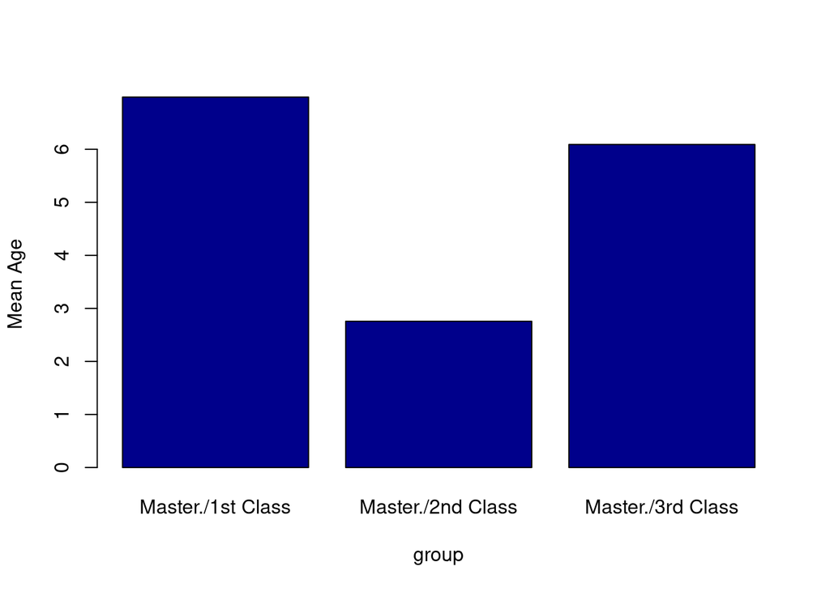

```r
mmas1 <- mean(no_na_titan$Age[no_na_titan$title == "Master." & no_na_titan$Pclass == 1])
mmas2 <- mean(no_na_titan$Age[no_na_titan$title == "Master." & no_na_titan$Pclass == 2])
mmas3 <- mean(no_na_titan$Age[no_na_titan$title == "Master." & no_na_titan$Pclass == 3])

master <- c(mmas1, mmas2, mmas3)
barplot(master, xlab = 'group', ylab = 'Mean Age', names.arg = c('Master./1st Class', 'Master./2nd Class', 'Master./3rd Class'), col = 'darkblue')
```

Comprovem si hi ha outliers:

```r
boxplot.stats(third_cl$Age[third_cl$title == "Master."])$out
```

```
## numeric(0)
```

Imputem valors només pels passatgers de tercera classe:

```r
imp_master_3 <- mean(third_cl$Age[third_cl$title == "Master."])
```

```r
titan$Age[is.na(titan$Age) & titan$title == "Master." & titan$Pclass == 3] <- imp_master_3
titan$Age[titan$title == "Master." & titan$Pclass == 3]
```

```
##  [1]  2.00  2.00  7.00 11.00  4.00  6.09 12.00  6.09  1.00  9.00  4.00  6.09
## [13]  9.00  3.00  7.00  3.00  1.00  9.00  9.00  6.09  6.00  8.00  1.00  0.42
## [25] 10.00  2.00  4.00  4.00  9.00 10.00  6.00 13.00  7.00 11.50  0.33  6.09
## [37]  0.75  0.83  6.09  6.09 14.50  5.00  6.00 13.00  6.09
```

Busquem valors buits al grup amb títol ‘Miss.’:

```r
titan$Age[titan$title == "Miss." & titan$Pclass == 1]
```

```
##  [1] 58 38 23 19 50 58 31 32 30 35 35 63 26  2 NA 30 24 18 31 36 16 41 24 22 42
## [26] 23 33 14 54 16 30 30 22 36 18 40 21 15 22 38 29 21 39 30 16 19 22 28 36 35
## [51] 36 33 29 33 21 39 31 45 30 22
```

```r
titan$Age[titan$title == "Miss." & titan$Pclass == 2]
```

```
##  [1]  3.00 21.00  5.00 17.00 32.50 24.00 35.00  8.00    NA 30.00 24.00 40.00
## [13] 38.00 36.00 17.00 18.00 19.00 13.00 50.00 50.00  2.00  7.00 34.00 25.00
## [25]    NA 24.00  4.00 28.00 18.00 27.00  6.00 30.00  4.00 27.00 20.00 12.00
## [37] 26.00 15.00 20.00 21.00  8.00 30.00 18.00  0.92 19.00 20.00  1.00 12.00
## [49] 31.00 24.00
```

```r
titan$Age[titan$title == "Miss." & titan$Pclass == 3]
```

```
##   [1] 26.00  4.00 14.00 15.00  8.00    NA    NA 18.00 14.00 19.00    NA 17.00
##  [13] 16.00 30.00    NA 28.00 21.00    NA 14.50 20.00 17.00  2.00    NA 22.00
##  [25]  9.00 16.00  1.00    NA  4.00 19.00    NA  2.00 16.00 27.00    NA  5.00
##  [37]    NA    NA    NA 25.00    NA    NA 45.00 22.00 24.00    NA 26.00    NA
##  [49]    NA    NA    NA  3.00 22.00  1.00 31.00 21.00 20.00    NA 10.00 21.00
##  [61]  5.00  0.75 22.00  2.00    NA 21.00    NA 37.00 30.00  9.00 11.00 22.00
##  [73]    NA    NA    NA    NA  9.00  2.00  0.75 23.00    NA 18.00 18.00    NA
##  [85]  4.00    NA 18.00    NA 25.00 30.50  5.00 13.00 18.00    NA 18.00  6.00
##  [97] 23.00  9.00    NA 15.00 22.00    NA 30.00 27.00    NA 21.00 22.00 18.00
## [109] 24.00 29.00 24.00 27.00 18.00 20.00    NA 18.50  1.00 17.00    NA 23.00
## [121] 10.00 23.00    NA 22.00    NA 18.00    NA 35.00 38.00    NA    NA  1.00
## [133]    NA    NA 23.00    NA  9.00  2.00 30.00    NA 37.00 17.00 16.00  0.17
## [145] 22.00 22.00    NA  3.00    NA 28.00
```

Visualitzem les diferents mitjanes d’edat:

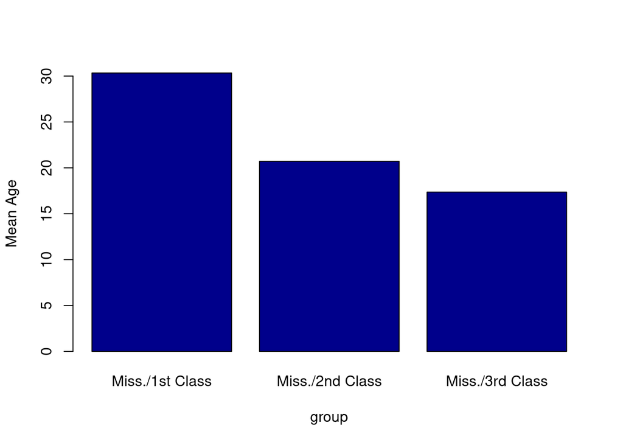

```r
miss1 <- mean(no_na_titan$Age[no_na_titan$title == "Miss." & no_na_titan$Pclass == 1])
miss2 <- mean(no_na_titan$Age[no_na_titan$title == "Miss." & no_na_titan$Pclass == 2])
miss3 <- mean(no_na_titan$Age[no_na_titan$title == "Miss." & no_na_titan$Pclass == 3])

miss <- c(miss1, miss2, miss3)
barplot(miss, xlab = 'group', ylab = 'Mean Age', names.arg = c('Miss./1st Class', 'Miss./2nd Class', 'Miss./3rd Class'), col = 'darkblue')
```

Comprovem outliers:

```r
boxplot.stats(first_cl$Age[first_cl$title == "Miss."])$out
```

```
## [1] 58 58 63
```

```r
boxplot.stats(second_cl$Age[second_cl$title == "Miss."])$out
```

```
## numeric(0)
```

```r
boxplot.stats(third_cl$Age[third_cl$title == "Miss."])$out
```

```
## [1] 45
```

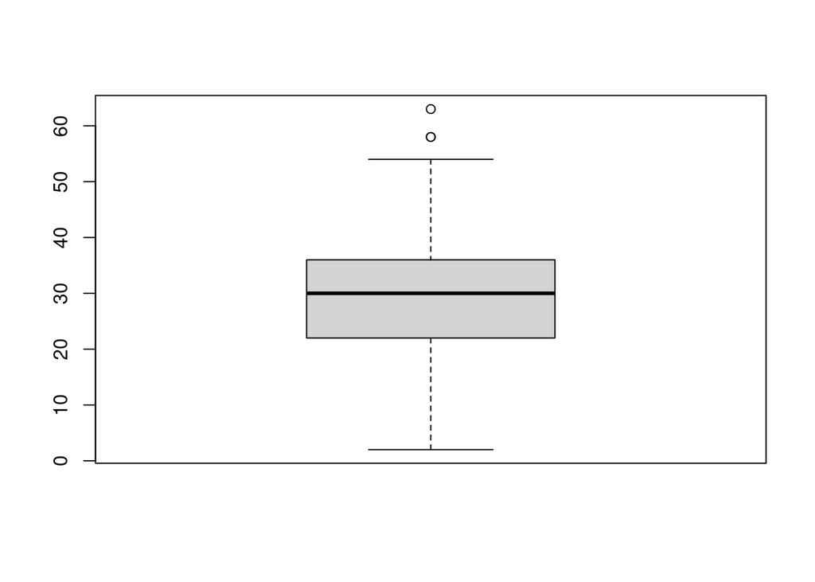

```r
boxplot(first_cl$Age[first_cl$title == "Miss."])
```

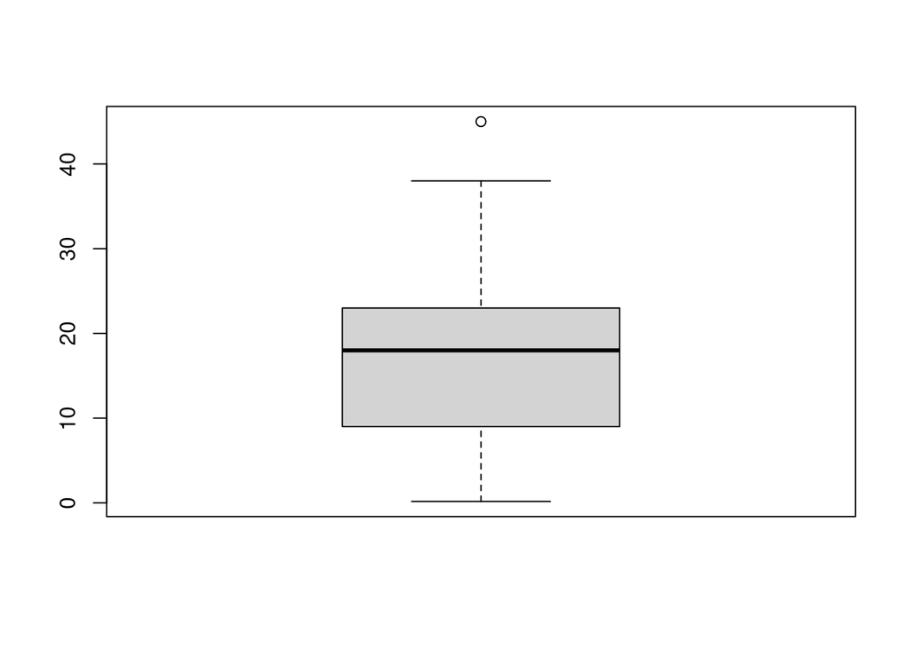

```r
boxplot(third_cl$Age[third_cl$title == "Miss."])
```

```r
mean(first_cl$Age[first_cl$title == "Miss."])
```

```
## [1] 30.33898
```

```r
median(first_cl$Age[first_cl$title == "Miss."])
```

```
## [1] 30
```

```r
mean(third_cl$Age[third_cl$title == "Miss."])
```

```
## [1] 17.36087
```

```r
median(third_cl$Age[third_cl$title == "Miss."])
```

```
## [1] 18
```

En aquest cas, veiem que els outliers detectats no donen suport a un canvi d’estratègia. En els dos casos, la diferència entre mitjana i mediana és mínima. Seguim doncs utilitzant la mitjana per imputar valors nuls en ambdós grups.

```r
imp_miss_1 <- mean(first_cl$Age[first_cl$title == "Miss."])
imp_miss_2 <- mean(second_cl$Age[second_cl$title == "Miss."])
imp_miss_3 <- mean(third_cl$Age[third_cl$title == "Miss."])
imp_miss_1
```

```
## [1] 30.33898
```

```r
imp_miss_2
```

```
## [1] 20.71708
```

```r
imp_miss_3
```

```
## [1] 17.36087
```

```r
titan$Age[is.na(titan$Age) & titan$title == "Miss." & titan$Pclass == 1] <- imp_miss_1
titan$Age[titan$title == "Miss." & titan$Pclass == 1]
```

```
##  [1] 58.00000 38.00000 23.00000 19.00000 50.00000 58.00000 31.00000 32.00000
##  [9] 30.00000 35.00000 35.00000 63.00000 26.00000  2.00000 30.33898 30.00000
## [17] 24.00000 18.00000 31.00000 36.00000 16.00000 41.00000 24.00000 22.00000
## [25] 42.00000 23.00000 33.00000 14.00000 54.00000 16.00000 30.00000 30.00000
## [33] 22.00000 36.00000 18.00000 40.00000 21.00000 15.00000 22.00000 38.00000
## [41] 29.00000 21.00000 39.00000 30.00000 16.00000 19.00000 22.00000 28.00000
## [49] 36.00000 35.00000 36.00000 33.00000 29.00000 33.00000 21.00000 39.00000
## [57] 31.00000 45.00000 30.00000 22.00000
```

```r
titan$Age[is.na(titan$Age) & titan$title == "Miss." & titan$Pclass == 2] <- imp_miss_2
titan$Age[titan$title == "Miss." & titan$Pclass == 2]
```

```
##  [1]  3.00000 21.00000  5.00000 17.00000 32.50000 24.00000 35.00000  8.00000
##  [9] 20.71708 30.00000 24.00000 40.00000 38.00000 36.00000 17.00000 18.00000
## [17] 19.00000 13.00000 50.00000 50.00000  2.00000  7.00000 34.00000 25.00000
## [25] 20.71708 24.00000  4.00000 28.00000 18.00000 27.00000  6.00000 30.00000
## [33]  4.00000 27.00000 20.00000 12.00000 26.00000 15.00000 20.00000 21.00000
## [41]  8.00000 30.00000 18.00000  0.92000 19.00000 20.00000  1.00000 12.00000
## [49] 31.00000 24.00000
```

```r
titan$Age[is.na(titan$Age) & titan$title == "Miss." & titan$Pclass == 3] <- imp_miss_3
titan$Age[titan$title == "Miss." & titan$Pclass == 3]
```

```
##   [1] 26.00000  4.00000 14.00000 15.00000  8.00000 17.36087 17.36087 18.00000
##   [9] 14.00000 19.00000 17.36087 17.00000 16.00000 30.00000 17.36087 28.00000
##  [17] 21.00000 17.36087 14.50000 20.00000 17.00000  2.00000 17.36087 22.00000
##  [25]  9.00000 16.00000  1.00000 17.36087  4.00000 19.00000 17.36087  2.00000
##  [33] 16.00000 27.00000 17.36087  5.00000 17.36087 17.36087 17.36087 25.00000
##  [41] 17.36087 17.36087 45.00000 22.00000 24.00000 17.36087 26.00000 17.36087
##  [49] 17.36087 17.36087 17.36087  3.00000 22.00000  1.00000 31.00000 21.00000
##  [57] 20.00000 17.36087 10.00000 21.00000  5.00000  0.75000 22.00000  2.00000
##  [65] 17.36087 21.00000 17.36087 37.00000 30.00000  9.00000 11.00000 22.00000
##  [73] 17.36087 17.36087 17.36087 17.36087  9.00000  2.00000  0.75000 23.00000
##  [81] 17.36087 18.00000 18.00000 17.36087  4.00000 17.36087 18.00000 17.36087
##  [89] 25.00000 30.50000  5.00000 13.00000 18.00000 17.36087 18.00000  6.00000
##  [97] 23.00000  9.00000 17.36087 15.00000 22.00000 17.36087 30.00000 27.00000
## [105] 17.36087 21.00000 22.00000 18.00000 24.00000 29.00000 24.00000 27.00000
## [113] 18.00000 20.00000 17.36087 18.50000  1.00000 17.00000 17.36087 23.00000
## [121] 10.00000 23.00000 17.36087 22.00000 17.36087 18.00000 17.36087 35.00000
## [129] 38.00000 17.36087 17.36087  1.00000 17.36087 17.36087 23.00000 17.36087
## [137]  9.00000  2.00000 30.00000 17.36087 37.00000 17.00000 16.00000  0.17000
## [145] 22.00000 22.00000 17.36087  3.00000 17.36087 28.00000
```

Busquem valors buits al grup ‘Mrs.’:

```r
titan$Age[titan$title == "Mrs." & titan$Pclass == 1]
```

```
##  [1] 38 35 NA 49 22 NA 44 35 NA 58 19 50 17 40 NA 60 NA 35 NA 35 25 54 44 39 53
## [26] 39 39 52 NA 18 36 51 43 17 33 52 62 NA 45 48 47 56 23 47 NA 48 45 60 60 55
## [51] 27 76 43 63 35 23 NA 64 18 27 50 53 48 55 26 64 55 58 45 59 25 45 54 51 18
## [76] 48 37
```

```r
titan$Age[titan$title == "Mrs." & titan$Pclass == 2]
```

```
##  [1] 14 55 27 29 29 34 29 40 32 24 50 41 26 24 22 36 28 34 28 42 24 45 33 23 33
## [26] 34 36 19 24 22 40 45 30 48 57 54 31 44 42 28 25 24 30 NA 29 36 60 22 45 22
## [51] 29 29 48 24 31
```

```r
titan$Age[titan$title == "Mrs." & titan$Pclass == 3]
```

```
##  [1] 27 31 NA 38 40 18 33 47 NA 24 45 NA 29 41 29 35 31 NA 45 NA 24 NA 28 NA 63
## [26] NA 36 29 NA 39 26 41 32 43 48 31 30 27 15 18 24 39 47 22 18 45 33 NA 36 22
## [51] 16 NA 36 26 26 NA NA NA 45 19 38 30 NA NA 19
```

Visualitzem les diferències d’edat entre grups:

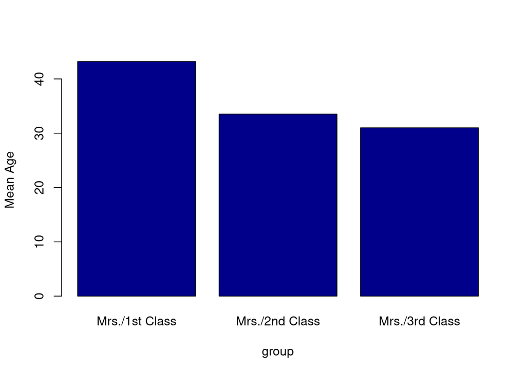

```r
mrs1 <- mean(no_na_titan$Age[no_na_titan$title == "Mrs." & no_na_titan$Pclass == 1])
mrs2 <- mean(no_na_titan$Age[no_na_titan$title == "Mrs." & no_na_titan$Pclass == 2])
# En el grup de tercera classe, la presència d'outliers ens fa optar per utilitzar la mediana
mrs3 <- median(no_na_titan$Age[no_na_titan$title == "Mrs." & no_na_titan$Pclass == 3])

mrs <- c(mrs1, mrs2, mrs3)
barplot(mrs, xlab = 'group', ylab = 'Mean Age', names.arg = c('Mrs./1st Class', 'Mrs./2nd Class', 'Mrs./3rd Class'), col = 'darkblue')
```

Comprovem outliers:

```r
boxplot.stats(first_cl$Age[first_cl$title == "Mrs."])$out
```

```
## numeric(0)
```

```r
boxplot.stats(second_cl$Age[second_cl$title == "Mrs."])$out
```

```
## numeric(0)
```

```r
boxplot.stats(third_cl$Age[third_cl$title == "Mrs."])$out
```

```
## [1] 63
```

```r
mean(third_cl$Age[third_cl$title == "Mrs."])
```

```
## [1] 32.32653
```

```r
median(third_cl$Age[third_cl$title == "Mrs."])
```

```
## [1] 31
```

En aquest cas sí que veiem que un únic valor (63) afecta la mitjana d’edat de les passatgeres ‘Mrs.’ de tercera classe. En aquest cas concret doncs, només pel grup de tercera classe, optarem per utilitzar la mediana per fer la imputació.

```r
imp_mrs_1 <- mean(first_cl$Age[first_cl$title == "Mrs."])
imp_mrs_2 <- mean(second_cl$Age[second_cl$title == "Mrs."])
imp_mrs_3 <- median(third_cl$Age[third_cl$title == "Mrs."])
imp_mrs_1
```

```
## [1] 43.20896
```

```r
imp_mrs_2
```

```
## [1] 33.51852
```

```r
imp_mrs_3
```

```
## [1] 31
```

```r
titan$Age[is.na(titan$Age) & titan$title == "Mrs." & titan$Pclass == 1] <- imp_mrs_1
titan$Age[titan$title == "Mrs." & titan$Pclass == 1]
```

```
##  [1] 38.00000 35.00000 43.20896 49.00000 22.00000 43.20896 44.00000 35.00000
##  [9] 43.20896 58.00000 19.00000 50.00000 17.00000 40.00000 43.20896 60.00000
## [17] 43.20896 35.00000 43.20896 35.00000 25.00000 54.00000 44.00000 39.00000
## [25] 53.00000 39.00000 39.00000 52.00000 43.20896 18.00000 36.00000 51.00000
## [33] 43.00000 17.00000 33.00000 52.00000 62.00000 43.20896 45.00000 48.00000
## [41] 47.00000 56.00000 23.00000 47.00000 43.20896 48.00000 45.00000 60.00000
## [49] 60.00000 55.00000 27.00000 76.00000 43.00000 63.00000 35.00000 23.00000
## [57] 43.20896 64.00000 18.00000 27.00000 50.00000 53.00000 48.00000 55.00000
## [65] 26.00000 64.00000 55.00000 58.00000 45.00000 59.00000 25.00000 45.00000
## [73] 54.00000 51.00000 18.00000 48.00000 37.00000
```

```r
titan$Age[is.na(titan$Age) & titan$title == "Mrs." & titan$Pclass == 2] <- imp_mrs_2
titan$Age[titan$title == "Mrs." & titan$Pclass == 2]
```

```
##  [1] 14.00000 55.00000 27.00000 29.00000 29.00000 34.00000 29.00000 40.00000
##  [9] 32.00000 24.00000 50.00000 41.00000 26.00000 24.00000 22.00000 36.00000
## [17] 28.00000 34.00000 28.00000 42.00000 24.00000 45.00000 33.00000 23.00000
## [25] 33.00000 34.00000 36.00000 19.00000 24.00000 22.00000 40.00000 45.00000
## [33] 30.00000 48.00000 57.00000 54.00000 31.00000 44.00000 42.00000 28.00000
## [41] 25.00000 24.00000 30.00000 33.51852 29.00000 36.00000 60.00000 22.00000
## [49] 45.00000 22.00000 29.00000 29.00000 48.00000 24.00000 31.00000
```

```r
titan$Age[is.na(titan$Age) & titan$title == "Mrs." & titan$Pclass == 3] <- imp_mrs_3
titan$Age[titan$title == "Mrs." & titan$Pclass == 3]
```

```
##  [1] 27 31 31 38 40 18 33 47 31 24 45 31 29 41 29 35 31 31 45 31 24 31 28 31 63
## [26] 31 36 29 31 39 26 41 32 43 48 31 30 27 15 18 24 39 47 22 18 45 33 31 36 22
## [51] 16 31 36 26 26 31 31 31 45 19 38 30 31 31 19
```

Trobem valors buits al grup ‘Mr.’:

```r
titan$Age[titan$title == "Mr." & titan$Pclass == 1]
```

```
##   [1] 54.0 28.0 19.0 28.0 42.0 65.0   NA 45.0   NA 28.0 46.0 71.0 23.0 21.0 47.0
##  [16] 24.0 54.0 37.0 24.0 51.0   NA 61.0 56.0   NA 45.0 40.0 38.0 37.0 62.0 52.0
##  [31] 40.0   NA 37.0   NA   NA   NA 45.5 38.0 29.0 45.0   NA 25.0 22.0 27.0 36.0
##  [46] 28.0 50.0 64.0 34.0 30.0 49.0 65.0 48.0 47.0 56.0   NA 25.0 58.0 55.0 71.0
##  [61] 18.0   NA 36.0 47.0   NA 50.0 64.0 17.0 62.0   NA 36.0 36.0 60.0   NA 35.0
##  [76] 27.0 42.0 61.0 80.0   NA 48.0 58.0 47.0 31.0 36.0 27.0 31.0 49.0 35.0 42.0
##  [91]   NA 48.0 27.0 35.0   NA 36.0 19.0 29.0 46.0   NA 39.0   NA   NA 51.0 31.0
## [106] 33.0 26.0 46.0 55.0 21.0 41.0 30.0   NA 45.0 24.0 47.0 31.0 28.5 32.5 67.0
## [121] 49.0 25.0 36.0 61.0 42.0   NA   NA 42.0 48.0 54.0 37.0   NA   NA 42.0 57.0
## [136] 39.0 64.0 45.0 41.0 27.0   NA 46.0 24.0   NA 30.0 30.0 55.0 57.0 33.0 46.0
## [151] 39.0 30.0 50.0 49.0 55.0 23.0 17.0 43.0 50.0
```

```r
titan$Age[titan$title == "Mr." & titan$Pclass == 2]
```

```
##   [1]   NA 35.0 34.0 66.0 32.0 21.0 34.0 29.0 21.0 32.5 25.0 23.0 18.0 19.0 36.5
##  [16] 30.0   NA 19.0 30.0 42.0 30.0 27.0 19.0 18.0 59.0 24.0 44.0 19.0 33.0 29.0
##  [31] 36.0   NA 42.0 36.0 30.0 43.0 28.0 25.0 36.0 29.0 18.0 46.0 34.0   NA 30.0
##  [46] 31.0 36.0 48.0   NA 34.0   NA 23.0 32.0   NA 27.0 28.0 62.0 54.0 47.0 37.0
##  [61] 26.0 31.0 24.0 23.0 32.0 25.0 70.0 31.0   NA 60.0 25.0 52.0 39.0 52.0 34.0
##  [76] 50.0 25.0   NA 23.0 23.0 18.0 16.0 39.0 34.0 39.0 35.0 31.0 16.0 21.0 24.0
##  [91] 28.0 62.0 26.0 63.0 35.0 50.0 24.0 27.0   NA 32.0 30.0   NA 27.0 18.5 41.0
## [106] 42.0 26.0 28.0 30.0 40.0 40.0 34.0 61.0 23.0 25.0 24.0 17.0 36.0 14.0 42.0
## [121] 30.0 28.0 40.0 30.0 22.0   NA 43.0 19.0 22.0 26.0 29.0 21.0 32.0 25.0 18.0
## [136] 26.0 24.0 25.0 18.0 49.0 29.0 21.0 44.0 21.0   NA 57.0 47.0 38.0 20.0 23.0
```

```r
titan$Age[titan$title == "Mr." & titan$Pclass == 3]
```

```
##   [1] 22.0 35.0   NA 20.0 39.0   NA   NA   NA 21.0   NA   NA   NA   NA 21.0 28.5
##  [16] 22.0 19.0 26.0 26.0 32.0 25.0   NA   NA 22.0 29.0 16.0   NA 24.0 29.0 20.0
##  [31] 26.0 59.0   NA   NA 33.0 37.0 28.0   NA 38.0 22.0 21.0 70.5   NA   NA 24.0
##  [46] 45.0 33.0 20.0 16.0 19.0 27.0 55.5 40.5   NA 30.0   NA 44.0 26.0 17.0 28.0
##  [61] 21.0 18.0 36.0 40.0 36.0   NA 42.0 28.0   NA 34.0 45.5 18.0 32.0 26.0 24.0
##  [76] 22.0   NA 16.0 51.0   NA 22.0 20.5 29.0 22.0 30.0   NA 30.0   NA 16.0 25.0
##  [91] 25.0 65.0 28.0 16.0 19.0 33.0 30.0 22.0 24.0 23.5   NA 19.0   NA 28.0 22.0
## [106] 27.0   NA 61.0 16.0   NA 45.0 42.0 23.0 15.0 25.0   NA 28.0 40.0 35.0   NA
## [121] 30.0 18.0 19.0 20.0 19.0 32.0   NA   NA 21.0 28.0 22.0 39.0 26.0 28.0 51.0
## [136] 21.0   NA   NA 44.0   NA 21.0 29.0 18.0   NA   NA 32.0 17.0 20.0 25.0   NA
## [151]   NA   NA 29.0   NA 34.0   NA 38.0   NA   NA 38.0 29.0 22.0 50.0 30.0   NA
## [166] 21.0 21.0   NA   NA 24.0 17.0 28.0 26.0 29.0   NA 24.0   NA 32.0 22.0   NA
## [181]   NA 40.5 39.0   NA 17.0   NA 33.0   NA 22.0   NA 40.0   NA 24.0 19.0   NA
## [196] 32.0 16.0 19.0 32.0   NA 22.0   NA 35.0 47.0 36.0 49.0   NA   NA 44.0 36.0
## [211] 30.0   NA   NA 35.0 34.0 27.0 20.0 21.0 21.0 26.0   NA 51.0 32.0   NA 20.0
## [226]   NA 19.0   NA   NA 21.0   NA 40.0 36.0 20.0   NA 43.0 18.0 24.5 20.0 14.0
## [241] 14.0 19.0 18.0   NA 25.0 44.0 42.0 25.0 26.0 29.0 19.0   NA 33.0 17.0 20.0
## [256] 11.0 28.5   NA   NA 24.0 31.0 16.0 31.0 33.0 23.0 28.0 34.0   NA 41.0 20.0
## [271] 16.0   NA 32.0 24.0 48.0   NA 18.0   NA   NA   NA 25.0 25.0   NA 25.0 30.0
## [286] 27.0 31.0 26.0 39.0 30.5 43.0 27.0   NA   NA   NA   NA 23.0 18.0 21.0   NA
## [301] 32.0 20.0 34.5 17.0 42.0   NA 35.0 74.0   NA 41.0   NA 26.0 47.0 20.0 19.0
## [316]   NA 33.0 25.0 32.0 34.5 27.0 14.0 21.0   NA 21.0 50.0 22.5   NA 18.5 25.0
## [331]   NA 39.0 41.0 25.0   NA 35.0 25.0   NA 17.0 18.0 21.0   NA   NA   NA   NA
## [346]   NA 25.0 29.0 33.0   NA 26.0 28.0 21.0   NA   NA 18.0   NA   NA 28.0   NA
## [361] 22.0 24.0 32.0   NA 43.0 24.0 26.5 40.0 31.0 22.0   NA 60.5 24.0   NA 18.0
## [376]   NA 27.0 23.0   NA 40.0   NA 17.0 33.0 25.0 32.0   NA   NA 21.0 21.0 23.0
## [391] 40.5 21.0   NA 20.0 20.0   NA 20.0 24.0 32.5   NA   NA 28.0 21.0 36.5 21.0
## [406]   NA   NA 17.0   NA   NA 36.0   NA   NA   NA   NA 36.0 26.0   NA 29.0 32.0
## [421] 24.0 18.0 22.0   NA 27.0 26.0 25.0 23.0   NA 27.0 39.0 32.0   NA   NA   NA
## [436] 27.0   NA   NA 26.0 24.0 21.0 29.0 24.0 22.0 31.0   NA 38.5   NA
```

Visualitzem diferències d’edat pel grup ‘Mr.’:

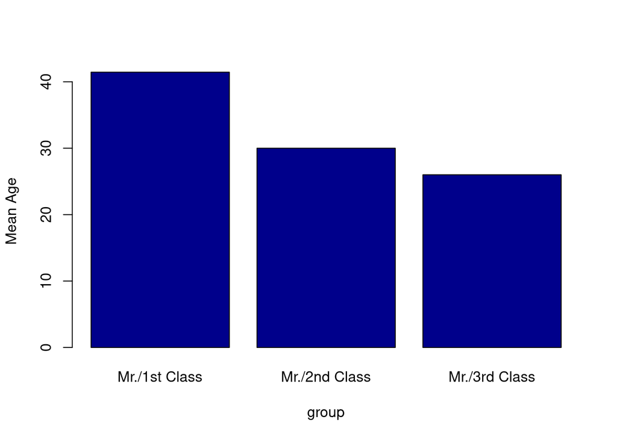

```r
mr1 <- mean(no_na_titan$Age[no_na_titan$title == "Mr." & no_na_titan$Pclass == 1])
# Com que els outliers influeixen sobre la mitjana, utilitzem la mediana pels grups de segona i tercera classe
mr2 <- median(no_na_titan$Age[no_na_titan$title == "Mr." & no_na_titan$Pclass == 2])
mr3 <- median(no_na_titan$Age[no_na_titan$title == "Mr." & no_na_titan$Pclass == 3])

mr <- c(mr1, mr2, mr3)
barplot(mr, xlab = 'group', ylab = 'Mean Age', names.arg = c('Mr./1st Class', 'Mr./2nd Class', 'Mr./3rd Class'), col = 'darkblue')
```

Comprovem outliers:

```r
boxplot.stats(first_cl$Age[first_cl$title == "Mr."])$out
```

```
## numeric(0)
```

```r
boxplot.stats(second_cl$Age[second_cl$title == "Mr."])$out
```

```
## [1] 66 62 70 60 62 63 61
```

```r
boxplot.stats(third_cl$Age[third_cl$title == "Mr."])$out
```

```
## [1] 59.0 70.5 55.5 65.0 61.0 74.0 60.5
```

```r
mean(second_cl$Age[second_cl$title == "Mr."])
```

```
## [1] 32.34672
```

```r
median(second_cl$Age[second_cl$title == "Mr."])
```

```
## [1] 30
```

```r
mean(third_cl$Age[third_cl$title == "Mr."])
```

```
## [1] 28.31891
```

```r
median(third_cl$Age[third_cl$title == "Mr."])
```

```
## [1] 26
```

En els grups de segona i tercera també optarem per utilitzar la mediana en lloc de la mitjana.

```r
imp_mr_1 <- mean(first_cl$Age[first_cl$title == "Mr."])
imp_mr_2 <- median(second_cl$Age[second_cl$title == "Mr."])
imp_mr_3 <- median(third_cl$Age[third_cl$title == "Mr."])
imp_mr_1
```

```
## [1] 41.45076
```

```r
imp_mr_2
```

```
## [1] 30
```

```r
imp_mr_3
```

```
## [1] 26
```

Imputem els valors:

```r
titan$Age[is.na(titan$Age) & titan$title == "Mr." & titan$Pclass == 1] <- imp_mr_1
titan$Age[titan$title == "Mr." & titan$Pclass == 1]
```

```
##   [1] 54.00000 28.00000 19.00000 28.00000 42.00000 65.00000 41.45076 45.00000
##   [9] 41.45076 28.00000 46.00000 71.00000 23.00000 21.00000 47.00000 24.00000
##  [17] 54.00000 37.00000 24.00000 51.00000 41.45076 61.00000 56.00000 41.45076
##  [25] 45.00000 40.00000 38.00000 37.00000 62.00000 52.00000 40.00000 41.45076
##  [33] 37.00000 41.45076 41.45076 41.45076 45.50000 38.00000 29.00000 45.00000
##  [41] 41.45076 25.00000 22.00000 27.00000 36.00000 28.00000 50.00000 64.00000
##  [49] 34.00000 30.00000 49.00000 65.00000 48.00000 47.00000 56.00000 41.45076
##  [57] 25.00000 58.00000 55.00000 71.00000 18.00000 41.45076 36.00000 47.00000
##  [65] 41.45076 50.00000 64.00000 17.00000 62.00000 41.45076 36.00000 36.00000
##  [73] 60.00000 41.45076 35.00000 27.00000 42.00000 61.00000 80.00000 41.45076
##  [81] 48.00000 58.00000 47.00000 31.00000 36.00000 27.00000 31.00000 49.00000
##  [89] 35.00000 42.00000 41.45076 48.00000 27.00000 35.00000 41.45076 36.00000
##  [97] 19.00000 29.00000 46.00000 41.45076 39.00000 41.45076 41.45076 51.00000
## [105] 31.00000 33.00000 26.00000 46.00000 55.00000 21.00000 41.00000 30.00000
## [113] 41.45076 45.00000 24.00000 47.00000 31.00000 28.50000 32.50000 67.00000
## [121] 49.00000 25.00000 36.00000 61.00000 42.00000 41.45076 41.45076 42.00000
## [129] 48.00000 54.00000 37.00000 41.45076 41.45076 42.00000 57.00000 39.00000
## [137] 64.00000 45.00000 41.00000 27.00000 41.45076 46.00000 24.00000 41.45076
## [145] 30.00000 30.00000 55.00000 57.00000 33.00000 46.00000 39.00000 30.00000
## [153] 50.00000 49.00000 55.00000 23.00000 17.00000 43.00000 50.00000
```

```r
titan$Age[is.na(titan$Age) & titan$title == "Mr." & titan$Pclass == 2] <- imp_mr_2
titan$Age[titan$title == "Mr." & titan$Pclass == 2]
```

```
##   [1] 30.0 35.0 34.0 66.0 32.0 21.0 34.0 29.0 21.0 32.5 25.0 23.0 18.0 19.0 36.5
##  [16] 30.0 30.0 19.0 30.0 42.0 30.0 27.0 19.0 18.0 59.0 24.0 44.0 19.0 33.0 29.0
##  [31] 36.0 30.0 42.0 36.0 30.0 43.0 28.0 25.0 36.0 29.0 18.0 46.0 34.0 30.0 30.0
##  [46] 31.0 36.0 48.0 30.0 34.0 30.0 23.0 32.0 30.0 27.0 28.0 62.0 54.0 47.0 37.0
##  [61] 26.0 31.0 24.0 23.0 32.0 25.0 70.0 31.0 30.0 60.0 25.0 52.0 39.0 52.0 34.0
##  [76] 50.0 25.0 30.0 23.0 23.0 18.0 16.0 39.0 34.0 39.0 35.0 31.0 16.0 21.0 24.0
##  [91] 28.0 62.0 26.0 63.0 35.0 50.0 24.0 27.0 30.0 32.0 30.0 30.0 27.0 18.5 41.0
## [106] 42.0 26.0 28.0 30.0 40.0 40.0 34.0 61.0 23.0 25.0 24.0 17.0 36.0 14.0 42.0
## [121] 30.0 28.0 40.0 30.0 22.0 30.0 43.0 19.0 22.0 26.0 29.0 21.0 32.0 25.0 18.0
## [136] 26.0 24.0 25.0 18.0 49.0 29.0 21.0 44.0 21.0 30.0 57.0 47.0 38.0 20.0 23.0
```

```r
titan$Age[is.na(titan$Age) & titan$title == "Mr." & titan$Pclass == 3] <- imp_mr_3
titan$Age[titan$title == "Mr." & titan$Pclass == 3]
```

```
##   [1] 22.0 35.0 26.0 20.0 39.0 26.0 26.0 26.0 21.0 26.0 26.0 26.0 26.0 21.0 28.5
##  [16] 22.0 19.0 26.0 26.0 32.0 25.0 26.0 26.0 22.0 29.0 16.0 26.0 24.0 29.0 20.0
##  [31] 26.0 59.0 26.0 26.0 33.0 37.0 28.0 26.0 38.0 22.0 21.0 70.5 26.0 26.0 24.0
##  [46] 45.0 33.0 20.0 16.0 19.0 27.0 55.5 40.5 26.0 30.0 26.0 44.0 26.0 17.0 28.0
##  [61] 21.0 18.0 36.0 40.0 36.0 26.0 42.0 28.0 26.0 34.0 45.5 18.0 32.0 26.0 24.0
##  [76] 22.0 26.0 16.0 51.0 26.0 22.0 20.5 29.0 22.0 30.0 26.0 30.0 26.0 16.0 25.0
##  [91] 25.0 65.0 28.0 16.0 19.0 33.0 30.0 22.0 24.0 23.5 26.0 19.0 26.0 28.0 22.0
## [106] 27.0 26.0 61.0 16.0 26.0 45.0 42.0 23.0 15.0 25.0 26.0 28.0 40.0 35.0 26.0
## [121] 30.0 18.0 19.0 20.0 19.0 32.0 26.0 26.0 21.0 28.0 22.0 39.0 26.0 28.0 51.0
## [136] 21.0 26.0 26.0 44.0 26.0 21.0 29.0 18.0 26.0 26.0 32.0 17.0 20.0 25.0 26.0
## [151] 26.0 26.0 29.0 26.0 34.0 26.0 38.0 26.0 26.0 38.0 29.0 22.0 50.0 30.0 26.0
## [166] 21.0 21.0 26.0 26.0 24.0 17.0 28.0 26.0 29.0 26.0 24.0 26.0 32.0 22.0 26.0
## [181] 26.0 40.5 39.0 26.0 17.0 26.0 33.0 26.0 22.0 26.0 40.0 26.0 24.0 19.0 26.0
## [196] 32.0 16.0 19.0 32.0 26.0 22.0 26.0 35.0 47.0 36.0 49.0 26.0 26.0 44.0 36.0
## [211] 30.0 26.0 26.0 35.0 34.0 27.0 20.0 21.0 21.0 26.0 26.0 51.0 32.0 26.0 20.0
## [226] 26.0 19.0 26.0 26.0 21.0 26.0 40.0 36.0 20.0 26.0 43.0 18.0 24.5 20.0 14.0
## [241] 14.0 19.0 18.0 26.0 25.0 44.0 42.0 25.0 26.0 29.0 19.0 26.0 33.0 17.0 20.0
## [256] 11.0 28.5 26.0 26.0 24.0 31.0 16.0 31.0 33.0 23.0 28.0 34.0 26.0 41.0 20.0
## [271] 16.0 26.0 32.0 24.0 48.0 26.0 18.0 26.0 26.0 26.0 25.0 25.0 26.0 25.0 30.0
## [286] 27.0 31.0 26.0 39.0 30.5 43.0 27.0 26.0 26.0 26.0 26.0 23.0 18.0 21.0 26.0
## [301] 32.0 20.0 34.5 17.0 42.0 26.0 35.0 74.0 26.0 41.0 26.0 26.0 47.0 20.0 19.0
## [316] 26.0 33.0 25.0 32.0 34.5 27.0 14.0 21.0 26.0 21.0 50.0 22.5 26.0 18.5 25.0
## [331] 26.0 39.0 41.0 25.0 26.0 35.0 25.0 26.0 17.0 18.0 21.0 26.0 26.0 26.0 26.0
## [346] 26.0 25.0 29.0 33.0 26.0 26.0 28.0 21.0 26.0 26.0 18.0 26.0 26.0 28.0 26.0
## [361] 22.0 24.0 32.0 26.0 43.0 24.0 26.5 40.0 31.0 22.0 26.0 60.5 24.0 26.0 18.0
## [376] 26.0 27.0 23.0 26.0 40.0 26.0 17.0 33.0 25.0 32.0 26.0 26.0 21.0 21.0 23.0
## [391] 40.5 21.0 26.0 20.0 20.0 26.0 20.0 24.0 32.5 26.0 26.0 28.0 21.0 36.5 21.0
## [406] 26.0 26.0 17.0 26.0 26.0 36.0 26.0 26.0 26.0 26.0 36.0 26.0 26.0 29.0 32.0
## [421] 24.0 18.0 22.0 26.0 27.0 26.0 25.0 23.0 26.0 27.0 39.0 32.0 26.0 26.0 26.0
## [436] 27.0 26.0 26.0 26.0 24.0 21.0 29.0 24.0 22.0 31.0 26.0 38.5 26.0
```

Comprovem finalment el grup ‘Ms.’:

```r
titan$Age[titan$title == "Ms." & titan$Pclass == 1]
```

```
## numeric(0)
```

```r
titan$Age[titan$title == "Ms." & titan$Pclass == 2]
```

```
## [1] 28
```

```r
titan$Age[titan$title == "Ms." & titan$Pclass == 3]
```

```
## [1] NA
```

En aquest cas no tenim referència. Imputarem l’únic valor nul amb la referència de la mitjana d’edat que hem creat anteriorment pel títol ‘Mrs.’ de tercera classe:

```r
titan$Age[is.na(titan$Age) & titan$title == "Ms." & titan$Pclass == 3] <- imp_mrs_3
titan$Age[titan$title == "Ms." & titan$Pclass == 3]
```

```
## [1] 31
```

```r
summary(titan$Age)
```

```
##    Min. 1st Qu.  Median    Mean 3rd Qu.    Max.
##    0.17   21.00   26.00   29.24   36.50   80.00
```

Detectem alguns valors buits a la variable ‘Embarked’:

```r
levels(titan$Embarked)
```

```
## [1] ""  "C" "Q" "S"
```

```r
summary(titan$Embarked)
```

```
##       C   Q   S
##   2 270 123 914
```

Mostrem els dos registres dels quals no disposem port d’embarcament:

```r
titan[titan$Embarked == "",]
```

```
##     Pclass                                      Name    Sex Age Fare Embarked
## 62       1                       Icard, Miss. Amelie female  38   80
## 830      1 Stone, Mrs. George Nelson (Martha Evelyn) female  62   80
##                                  ext_1 title
## 62                        Miss. Amelie Miss.
## 830 Mrs. George Nelson (Martha Evelyn)  Mrs.
```

No tenim manera d’imputar aquests valors, i per tant hi assignem NA:

```r
titan$Embarked[titan$Embarked == ""] <- NA
summary(titan$Embarked)
```

```
##         C    Q    S NA's
##    0  270  123  914    2
```

Detectem també un valor buit a la variable ‘Fare’;

```r
titan[is.na(titan$Fare),]
```

```
##      Pclass               Name  Sex  Age Fare Embarked      ext_1 title
## 1044      3 Storey, Mr. Thomas male 60.5   NA        S Mr. Thomas   Mr.
```

Trobem quina és la mitjana del preu del bitllet pels passatgers de tercera classe, i el fem servir per imputar aquest únic valor buit:

```r
fare_3rd <- mean(titan$Fare[!is.na(titan$Fare) & titan$Pclass == 3])
```

```r
titan$Fare[is.na(titan$Fare)] <- fare_3rd
```

```r
summary(titan)
```

```
##  Pclass      Name               Sex           Age             Fare
##  1:323   Length:1309        female:466   Min.   : 0.17   Min.   :  0.000
##  2:277   Class :character   male  :843   1st Qu.:21.00   1st Qu.:  7.896
##  3:709   Mode  :character                Median :26.00   Median : 14.454
##                                          Mean   :29.24   Mean   : 33.280
##                                          3rd Qu.:36.50   3rd Qu.: 31.275
##                                          Max.   :80.00   Max.   :512.329
##  Embarked      ext_1              title
##      :  0   Length:1309        Length:1309
##  C   :270   Class :character   Class :character
##  Q   :123   Mode  :character   Mode  :character
##  S   :914
##  NA's:  2
##
```

## 3.2 Altres valors extrems (outliers)

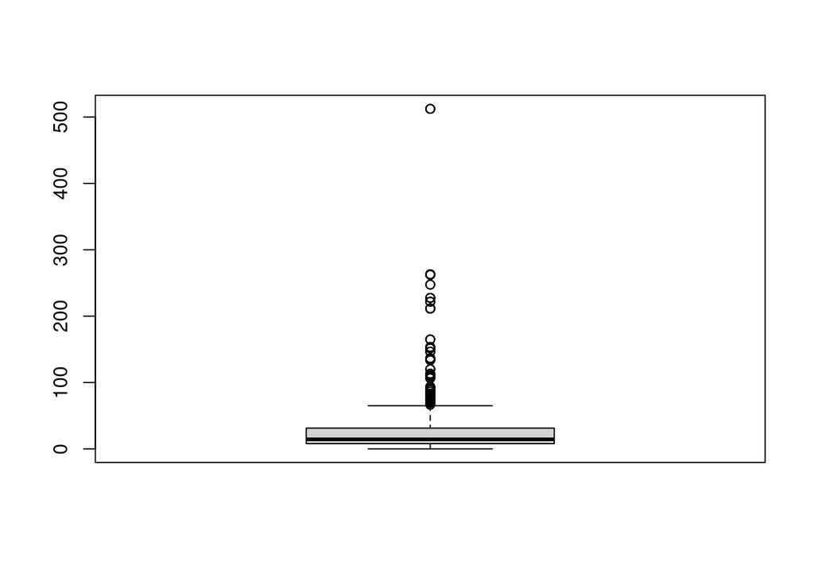

```r
boxplot(titan$Fare)
```

Veiem que hi ha 4 passatgers que paguen un preu molts més alt que la resta. Si examinem la resta dels valors, creiem que no es tracta de valors erronis:

```r
titan[titan$Fare > 400,]
```

```
##      Pclass                                                            Name
## 259       1                                                Ward, Miss. Anna
## 680       1                              Cardeza, Mr. Thomas Drake Martinez
## 738       1                                          Lesurer, Mr. Gustave J
## 1235      1 Cardeza, Mrs. James Warburton Martinez (Charlotte Wardle Drake)
##         Sex Age     Fare Embarked
## 259  female  35 512.3292        C
## 680    male  36 512.3292        C
## 738    male  35 512.3292        C
## 1235 female  58 512.3292        C
##                                                       ext_1 title
## 259                                              Miss. Anna Miss.
## 680                               Mr. Thomas Drake Martinez   Mr.
## 738                                           Mr. Gustave J   Mr.
## 1235 Mrs. James Warburton Martinez (Charlotte Wardle Drake)  Mrs.
```

Donem un nou nom al dataset amb totes les correccions fetes, i l’exportem a un fitxer csv:

```r
titanic1 <- titan
write.csv(titanic1, "titanic1.csv", row.names = FALSE)
```

# 4. Anàlisi de les dades

En aquesta secció farem l’anàlisi de les dades sota estudi. En concret estem interessats en els següents aspectes:

- Diferència de tarifa en funció del gènere del passatger.
- Relació entre el port d’embarcament i la classe.
- Mitjana d’edat dels passatgers a cadascuna de les classes.

## 4.1 Prova 1. Diferència de tarifa en funció del gènere del passatger.

En aquesta prova volem comprovar si hi ha diferències en la quantitat mitjana que han pagat homes i dones per a embarcar.

### 4.1.1 Selecció dels grups de dades a analitzar/comparar

En aquest cas farem una anàlisi d’una variable numèrica *Fare* respecte una variable categòrica *Sex*. Volem fer una prova de contrast d’hipòtesis en la que ens plantegem si en mitjana homes i dones han pagat el mateix pels seus bitllets.

Abans de començar a plantejar el test estadístic visualitzarem les diferències en la distribució de la variable *Fare* en funció de la variable *Sex* amb una gràfica boxplot.

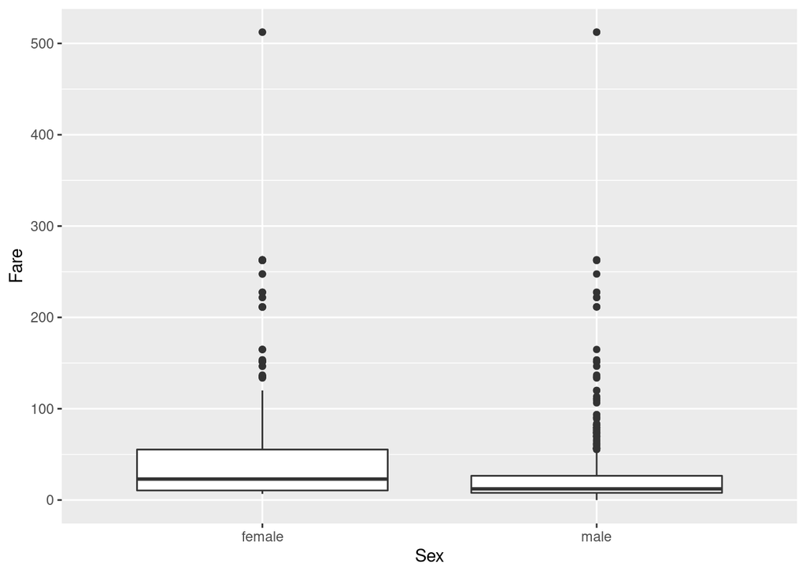

```r
# Boxplot tarifa segons sexe
ggplot(aes(y=Fare, x=Sex), data=titanic1) + geom_boxplot()
```

Veiem que, de mitjana, les dones paguen més que els homes. També veiem, però, que aquesta diferència sembla petita si tenim en compte la distribució total de la variable ‘Fare’ sobre els dos grups. La nostra prova doncs consistirà a determinar si la diferència de preus entre dones i homes és estadísticament significativa. D’acord amb les nostres observacions plantegem les següents hipòtesis nul·la i alternativa:

H<sub>0</sub> : 𝛍<sub>fare_f</sub> = 𝛍<sub>fare_m</sub>

H<sub>1</sub> : 𝛍<sub>fare_f</sub> > 𝛍<sub>fare_m</sub>

- *Hipòtesi nul·la*: les mitjanes de preu entre homes i dones és igual
- *Hipòtesi alternativa*: les dones paguen un preu més alt que els homes

### 4.1.2 Comprovació de la normalitat i de la variància

**Comprovació de la normalitat**  
En primer lloc farem una validació de la normalitat de la distribució de la variable *Fare*, tant visual amb una gràfica QQ-plot, com mitjançant el test estadístic de Shapiro-Wilk.

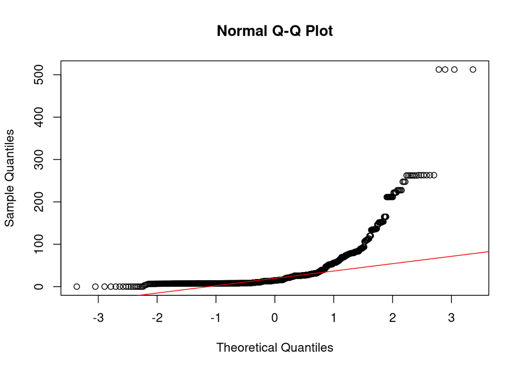

```r
# Comprovació visual amb QQ-plot
qqnorm(titanic1$Fare)
qqline(titanic1$Fare, col='red')
```

```r
# Test de Shapiro-Wilk
shapiro.test(titanic1$Fare)
```

```
##
##  Shapiro-Wilk normality test
##
## data:  titanic1$Fare
## W = 0.52766, p-value < 2.2e-16
```

La inspecció de la gràfica QQ-plot revela que la variable *Fare* no segueix la línia vermella que marca la distribució normal. El resultat del test de Shapiro-Wilk, en el que obtenim un p-value de l’ordre de $10^{-16}$ ens permet descartar la hipòtesi nul·la i arribar a la conclusió de que la variable *Fare* no segueix una distribució normal.

Malgrat el resultat de les proves i donat que farem tests sobre la mitjana, podem assumir segons el Teorema del Límit Central que la distribució de les mitjanes serà normal ja que disposem d’un nombre prou elevat de mostres.

**Comprovació de la variància**  
Per tal de determinar el tipus de test estadístic a aplicar en aquest cas cal comprovar prèviament les variàncies de les dues distribucions. Dividirem les mostres de la variable *Fare* segons el valor de la variable *Sex* i aplicarem la funció *var.test()*.

```r
# Les variàncies del preu en funció del sexe són iguals
fare_m <- titanic1[titanic1$Sex == 'male',]$Fare
fare_f <- titanic1[titanic1$Sex == 'female',]$Fare
var.test(fare_m,fare_f,conf.level = 0.95)
```

```
##
##  F test to compare two variances
##
## data:  fare_m and fare_f
## F = 0.45013, num df = 842, denom df = 465, p-value < 2.2e-16
## alternative hypothesis: true ratio of variances is not equal to 1
## 95 percent confidence interval:
##  0.3827350 0.5274003
## sample estimates:
## ratio of variances
##          0.4501268
```

El valor de p-value resultant, de l’ordre de $10^{-16}$, ens permet concloure que les dues variàncies són diferents amb un nivell de confiança del 95%. Donat que en aquest cas no es dona la condició d’homocedasticitat aplicarem un test sobre la mitjana de dues mostres independents, unilateral, amb variància desconeguda i diferent.

### 4.1.3 Aplicació de les proves estadístiques adients

Donat que en aquest cas no es dona la condició d’homocedasticitat aplicarem un test sobre la mitjana de dues mostres independents, unilateral, amb variància desconeguda i diferent.

```r
# Aplicació de la funció t.test() per al test estadístic unilateral
t.test(fare_f, fare_m, alternative = "greater", var.equal = FALSE)
```

```
##
##  Welch Two Sample t-test
##
## data:  fare_f and fare_m
## t = 6.122, df = 701.22, p-value = 7.69e-10
## alternative hypothesis: true difference in means is greater than 0
## 95 percent confidence interval:
##  14.66224      Inf
## sample estimates:
## mean of x mean of y
##  46.19810  26.13936
```

La prova estadística ens indica, amb un valor p per sota del nivell de significació, que podem rebutjar la hipòtesi nul·la. Per tant la conclusió és que la diferència de preu entre homes i dones és estadísticament significativa, i les dones paguen més que els homes.

Repetim la prova amb el test no paramètric de Wilcoxon, arribant a la mateixa conclusió:

```r
# Aplicació de la funció wilcox.test() per al test estadístic unilateral
wilcox.test(fare_f, fare_m, alternative = 'greater', conf.level=0.95)
```

```
##
##  Wilcoxon rank sum test with continuity correction
##
## data:  fare_f and fare_m
## W = 253656, p-value < 2.2e-16
## alternative hypothesis: true location shift is greater than 0
```

Després d’aplicar els dos tests, els valors de p-Value resultants ens permeten rebutjar la hipotesi nul·la i afirmar, amb un nivell de confiança del 95%, que en mitjana les dones paguen més pel bitllet que els homes.

Aquesta anàlisi no ha tingut en compte la classe en la que viatgen els passatgers, per tant caldria veure si aquest resultat és degut a que les dones viatgen, majoritàriament, a primera i segona classe.

## 4.2 Prova 2. Relació entre el port d’embarcament i la classe.

En aquesta provem volem comprovar si hi ha algun tipus de relació entre el port d’embarcament i la classe en la que viatgen els passatgers que hi embarquen.

### 4.2.1 Selecció dels grups de dades a analitzar/comparar

En aquest cas farem l’anàlisi de dues variables categòriques *Embarked* i *PClass* per tant caldrà aplicar un test Chi-squared.

A la taula següent visualitzarem quants atributs hi ha per a cada combinació de port d’embarcament i classe.

```r
table(titanic1$Pclass, titanic1$Embarked)
```

```
##
##           C   Q   S
##   1   0 141   3 177
##   2   0  28   7 242
##   3   0 101 113 495
```

Sembla que el port d’embarcament influeix sobre la classe del passatger. Veiem, per exemple, que al port de Queenstown hi embarquen majoritàriament passatgers de tercera classe, mentre que a Cherbourg són més nombrosos els passatgers de primera classe. D’acord amb aquesta observació plantegem les següents hipòtesis nul·la i alternativa:

H<sub>0</sub>: Les variables ‘PClass’ i ‘Embarked’ són independents

H<sub>1</sub>: Hi ha relació entre les variables ‘PClass’ i ‘Embarked’

### 4.2.2 Comprovació de la normalitat i de la variància

En aquest cas no aplica aquest apartat en tractar-se d’un test Chi-squared sobre dues variables categòriques.

### 4.2.3 Aplicació de les proves estadístiques adients

H<sub>0</sub>: Les variables ‘PClass’ i ‘Embarked’ són independents

H<sub>1</sub>: Hi ha relació entre les variables ‘PClass’ i ‘Embarked’

Sembla que el port d’embarcament influeix sobre la classe del passatger. Veiem, per exemple, que al port de Queenstown hi embarquen majoritàriament passatgers de tercera classe, mentre que a Cherbourg són més nombrosos els passatgers de primera classe.

```r
# Realització del test Chi-squared
cs <- chisq.test(titanic1$Pclass, titanic1$Embarked)
#Comprovem que el valor esperat de les cel·les sigui superior a 5 en el 80% dels casos:
cs$expected
```

```
##                titanic1$Embarked
## titanic1$Pclass         C        Q        S
##               1  66.31217 30.20888 224.4790
##               2  57.22265 26.06809 193.7093
##               3 146.46519 66.72303 495.8118
```

```r
cs
```

```
##
##  Pearson's Chi-squared test
##
## data:  titanic1$Pclass and titanic1$Embarked
## X-squared = 205.79, df = 4, p-value < 2.2e-16
```

Els resultats del test de chi quadrat confirmen les nostres sospites. Rebutgem la hipòtesi nul·la i acceptem la dependència de les dues variables amb un valor p < 0.01

## 4.3 Prova 3. Mitjana d’edat dels passatgers a cadascuna de les classes.

En aquest cas el nostre objectiu és comparar la mitjana d’edat dels passatgers del Titanic en funció de la classe en la que viatjaven i comprovar si hi ha diferències entre elles. Ja que es tracta d’una comparació de mitjanes entre més de dos grups de dades (al Titanic hi havia tres classes diferents) procedirem a aplicar un test d’ANOVA.

Tal i com hem fet a la *Prova 1* el primer pas serà comprovar les distribucions de la variable *Age* en funció de la variable *Pclass* amb gràfiques de tipus boxplot.

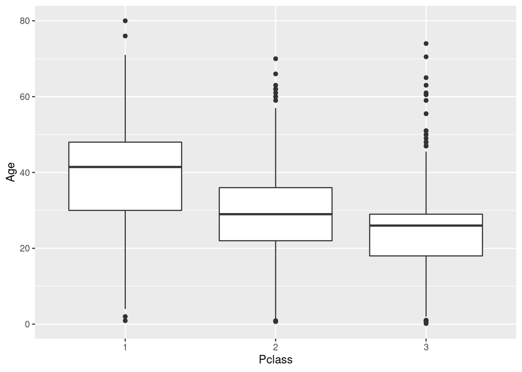

```r
ggplot(aes(y=Age, x=Pclass), data=titanic1) + geom_boxplot()
```

A les gràfiques observem que a primera classe la mitjana d’edat dels viatgers és més elevada que a segona i tercera, i que la caixa que representa l’IQR està més elevada, el que indica que l’edat dels passatgers a primera és major que a les altres dues. A partir de la gràfica es pot concloure que hi havia viatgers de més edat a primera classe i, per altra banda, hi havia viatgers més joves a tercera classe, quedant la segona classe en un intermedi.

### 4.3.1 Selecció dels grups de dades a analitzar/comparar

En aquest cas farem una anàlisi de la variable numèrica *Age* respecte la variable categòrica *Pclass*. Volem fer una prova de contrast d’hipòtesis en la que ens plantegem si en mitjana l’edat dels passatgers és la mateixa a totes les classes.

D’acord amb les nostres observacions plantegem les següents hipòtesis nul·la i alternativa:

Hipòtesi nul·la: la mitjana d’edat a totes les classes és la mateixa.  
Hipòtesi alternativa: les mitjanes d’edat són diferents a cada classe.

### 4.3.2 Comprovació de la normalitat i de la variància

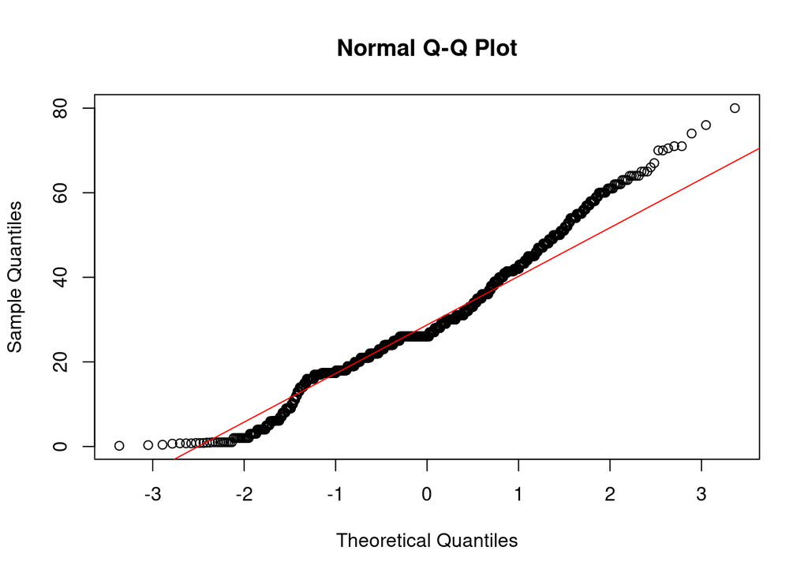

```r
# Comprovació visual amb QQ-plot
qqnorm(titanic1$Age)
qqline(titanic1$Age, col='red')
```

```r
# Test de Shapiro-Wilk
shapiro.test(titanic1$Age)
```

```
##
##  Shapiro-Wilk normality test
##
## data:  titanic1$Age
## W = 0.97091, p-value = 1.424e-15
```

La inspecció de la gràfica QQ-plot revela que la variable *Age* no segueix la línia vermella que marca la distribució normal, especialment als extrems de l’eix dabscisses. El resultat del test de Shapiro-Wilk, en el que obtenim un p-value de l’ordre de $10^{-15}$ ens permet descartar la hipòtesi nul·la i arribar a la conclusió de que la variable *Age* no segueix una distribució normal.

Tenint present aquesta manca de normalitat de la variable Age, crearem tanmateix un model ANOVA d’un sol factor (Pclass) sobre la variable, i un cop generat el model veurem si els residus del model també es desvien de la normal, i si cal fer llavors aplicar un test no paramètric.

### 4.3.3 Aplicació de les proves estadístiques adients

Generem un model linear i apliquem l’ANOVA d’un sol factor (amb tres nivells):

```r
resultat <- lm(Age~Pclass, data = titanic1)
table_1 <- anova(resultat)
table_1
```

```
## Analysis of Variance Table
##
## Response: Age
##             Df Sum Sq Mean Sq F value    Pr(>F)
## Pclass       2  49907 24953.7  174.69 < 2.2e-16 ***
## Residuals 1306 186560   142.8
## ---
## Signif. codes:  0 '***' 0.001 '**' 0.01 '*' 0.05 '.' 0.1 ' ' 1
```

Veiem que, efectivament, amb un nivell de significació amb valor p < 0.001, el model troba diferències significatives entre les mitjanes d’edats dels tres grups classe.

La variabilitat explicada de la variable Pclass sobre la variable Age seria d’un 21%:

```r
variabilitat <- 49907/(49907+186560)
variabilitat
```

```
## [1] 0.2110527
```

Si calculem els efectes de cada factor separadament, veiem que sobretot el factor 1a classe contribueix a l’augment d’edat, mentre que el factor 3a classe fa el contrari:

```r
resultat_2 <- aov(Age~Pclass, data = titanic1)
model.tables(resultat_2, type='effects')
```

```
## Tables of effects
##
##  Pclass
##          1       2       3
##      10.24   0.238  -4.757
## rep 323.00 277.000 709.000
```

Aplicarem un segon test que confirma els resultats:

```r
library(stats)
pairwise.t.test(titanic1$Age, titanic1$Pclass, p.adj='bonferroni')
```

```
##
##  Pairwise comparisons using t tests with pooled SD
##
## data:  titanic1$Age and titanic1$Pclass
##
##   1       2
## 2 < 2e-16 -
## 3 < 2e-16 1.4e-08
##
## P value adjustment method: bonferroni
```

Per avaluar l’adequació del model que hem generat, comprovem primer l’homocedasticitat dels residus:

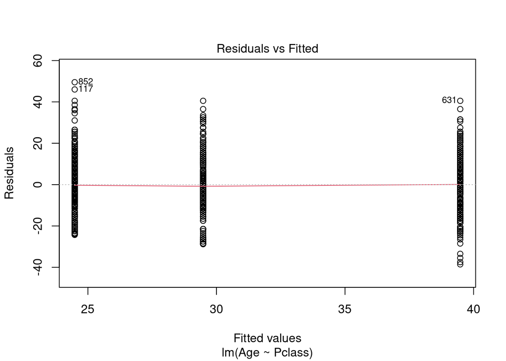

```r
plot(resultat, which = 1)
```

El gràfic no mostra un patró clar, i per tant podem afirmar que no hi ha un problema d’homocedasticitat.

En canvi, sí que observem una desvisació de la normalitat dels residus:

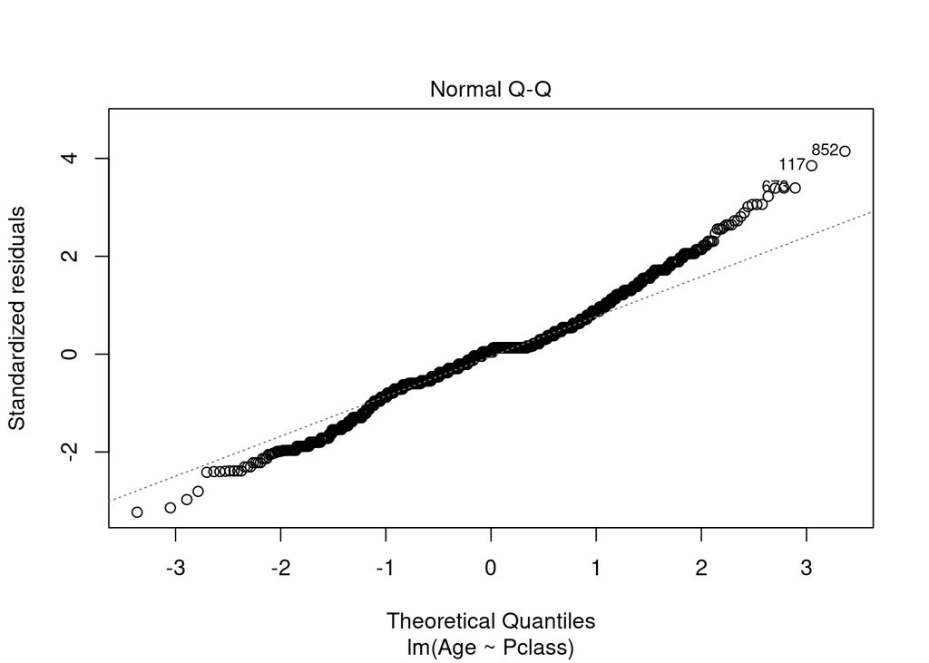

```r
plot(resultat, which = 2)
```

Així doncs, apliquem un test de Kruskal-Wallis, que no assumeix la normalitat de la distribució de les dades, i obtenim resultats que confirmen la diferència significativa entre grups:

```r
kruskal.test(Age~Pclass, data = titanic1)
```

```
##
##  Kruskal-Wallis rank sum test
##
## data:  Age by Pclass
## Kruskal-Wallis chi-squared = 263.96, df = 2, p-value < 2.2e-16
```

# 5. Representació gràfica dels resultats

Al llarg d’aquest document s’han anat presentant les gràfiques necessàries per a la interpretació dels resultats obtinguts, així com per a la visualització de les distribucions de les variables a analitzar.

# 6. Conclusions

El nostre estudi s’ha centrat en diverses de les variables contingudes en el dataset Titanic. Hem plantejat un estudi que deixa de banda el naufragi del Titanic, i hem aprofitat les diferents dades de caire demogràfic, social i econòmic per tal d’inverstigar la relació entre factors com l’edat dels passatgers, els preu del bitllet, la classe en què viatjaven i el port on van embarcar. D’alguna manera, podem considerar el grup de passatgers del Titanic com una mostra representativa de la població que migrava d’Europa a Estats Units a principis del segle XX. Les nostres conclusions en aquest sentit han de ser necessàriament provisionals i temptatives, tenint en compte que el Titanic no era un vaixell qualsevol, sinó precisament el més gran i modern que havia existit mai fins aquell moment. Tanmateix, si imaginem un estudi més ampli, on poguéssim accedir al mateix tipus de dades per altres vaixells de l’època, podem plantejar que el mateix tipus de relacions entre variables que hem presentat en aquest estudi ens podrien ajudar a fer comparacions i construir una imatge històrica, basada en l’anàlisi de dades, dels factors demogràfics i econòmics representatius d’aquest tipus concret de fenomen migratori de principis del segle XX.

Hem proposat una estratègia pròpia per imputar el gran nombre de valors buits que ens hem trobat a la variable ‘edat’, que era precisament una de les nostres principals variables d’interès.

Un cop netejades les dades, en la nostra investigació hem pogut constatar relacions estadísticament significatives entre el sexe i el preu del bitllet, entre la classe i el port d’embarcament, i entre l’edat i la classe. Respectivament, les proves estadístiques que hem realitzat ens permeten afirmar que les dones van pagar de mitjana un preu més alt per viatjar que els homes, que cadascun dels ports d’embarcament aglutinava viatgers de diferents classe en diferents proporcions, i que l’edat mitjana dels passatgers era diferent per cadascuna de les classes del viatgers.

# 7. Codi font per a la resolució de la pràctica

El present document HTML ha estat generat amb RStudio a partir d’un fitxer Rmd (R-markdown) que conté el codi necessari per al desenvolupament de la pràctica plantejada. Podeu consultar el fitxer Rmd amb el codi font en aquest mateix repositori.

| Contribucions | Firma |
| --- | --- |
| Investigació prèvia | Salvador Sanchis Beneseit i Joan Manuel Lopez Ruiz |
| Redacció de les respostes | Salvador Sanchis Beneseit i Joan Manuel Lopez Ruiz |
| Desenvolupament codi | Salvador Sanchis Beneseit i Joan Manuel Lopez Ruiz |